# MLwCaret

In diesem Notebook können Sie anhand der Analyse und verschiedener Modellierungen im Bikesharing-Datensatz nachvollziehen, wie Sie caret-Funktionen beim ML in R einsetzen können.

# Vorbereitungen

## Clear workspace

Löschen Sie die alte Umgebung, um in einem “neuen” R zu starten.

```r
rm(list=ls())
```

## Installieren von Packages

Falls Sie die in diesem Notebook benötigten Packages noch nicht haben (und nur dann), werden diese von CRAN noch nachinstalliert.

```r
if (!require("ggplot2")) install.packages("ggplot2")
if (!require("dplyr")) install.packages("dplyr")
if (!require("GGally")) install.packages("GGally")
if (!require("randomForest")) install.packages("randomForest")
if (!require("caret")) install.packages("caret")
if (!require("magrittr")) install.packages("magrittr")
if (!require("coefplot")) install.packages("coefplot")
```

## Funktion für SRH Optik aufrufen

Nur in der Demo-Version

## Daten laden und vorbereiten

Sie können die Daten aus dem Internet herunterladen, importieren und einem Preprocessing unterziehen. Wochentage, Arbeitstage, Datum und Wetterbedingungen sind folglich als passende Formate (Datum, Faktoren…) kodiert.

```r
library(dplyr)
bikesharing <- read.csv("https://raw.githubusercontent.com/christophM/interpretable-ml-book/master/data/bike-sharing-daily.csv")
bikesharing <- bikesharing %>%
  mutate(
    weekday_fct = factor(x = weekday,
             levels = c(0,1,2,3,4,5,6),
             labels = c("Sunday",
                       "Monday",
                       "Tuesday",
                       "Wednesday",
                       "Thursday",
                       "Friday",
                       "Saturday")))
bikesharing <- bikesharing %>%
    mutate(weathersit_fct = factor(x = weathersit,
              levels = c(1, 2, 3),
              labels = c("Good",
                       "Clouds/Mist",
                       "Rain/Snow/Storm")))
bikesharing <- bikesharing %>%
    mutate(season_fct = factor(x = season,
              levels = c(1, 2, 3, 4),
              labels = c("Spring",
                       "Summer",
                       "Fall",
                       "Winter")))
bikesharing$workingday <- as.factor(bikesharing$workingday)
bikesharing$weekday <- as.factor(bikesharing$weekday)
bikesharing$dteday <- as.Date(bikesharing$dteday)
bikesharing$weekday_fct <- as.character(bikesharing$weekday_fct)
```

# Explorative Datenanalyse

## Übersicht über den Datensatz

Sehen Sie sich die ersten sechs Zeilen des Datensatzes an.

```r
head(bikesharing)
```

|  | instant | dteday | season | yr | mnth | holiday | weekday | workingday | weathersit | temp | atemp | hum | windspeed | casual | registered | cnt | weekday_fct | weathersit_fct | season_fct |
| --- | --- | --- | --- | --- | --- | --- | --- | --- | --- | --- | --- | --- | --- | --- | --- | --- | --- | --- | --- |
| 1 | 1 | 2011-01-01 | 1 | 0 | 1 | 0 | 6 | 0 | 2 | 0.344167 | 0.363625 | 0.805833 | 0.1604460 | 331 | 654 | 985 | Saturday | Clouds/Mist | Spring |
| 2 | 2 | 2011-01-02 | 1 | 0 | 1 | 0 | 0 | 0 | 2 | 0.363478 | 0.353739 | 0.696087 | 0.2485390 | 131 | 670 | 801 | Sunday | Clouds/Mist | Spring |
| 3 | 3 | 2011-01-03 | 1 | 0 | 1 | 0 | 1 | 1 | 1 | 0.196364 | 0.189405 | 0.437273 | 0.2483090 | 120 | 1229 | 1349 | Monday | Good | Spring |
| 4 | 4 | 2011-01-04 | 1 | 0 | 1 | 0 | 2 | 1 | 1 | 0.200000 | 0.212122 | 0.590435 | 0.1602960 | 108 | 1454 | 1562 | Tuesday | Good | Spring |
| 5 | 5 | 2011-01-05 | 1 | 0 | 1 | 0 | 3 | 1 | 1 | 0.226957 | 0.229270 | 0.436957 | 0.1869000 | 82 | 1518 | 1600 | Wednesday | Good | Spring |
| 6 | 6 | 2011-01-06 | 1 | 0 | 1 | 0 | 4 | 1 | 1 | 0.204348 | 0.233209 | 0.518261 | 0.0895652 | 88 | 1518 | 1606 | Thursday | Good | Spring |

## Struktur

Sehen Sie sich Struktur und Aufbau des Datensatzes an

```r
str(bikesharing)
```

```
'data.frame':   731 obs. of  19 variables:
 $ instant       : int  1 2 3 4 5 6 7 8 9 10 ...
 $ dteday        : Date, format: "2011-01-01" "2011-01-02" "2011-01-03" "2011-01-04" ...
 $ season        : int  1 1 1 1 1 1 1 1 1 1 ...
 $ yr            : int  0 0 0 0 0 0 0 0 0 0 ...
 $ mnth          : int  1 1 1 1 1 1 1 1 1 1 ...
 $ holiday       : int  0 0 0 0 0 0 0 0 0 0 ...
 $ weekday       : Factor w/ 7 levels "0","1","2","3",..: 7 1 2 3 4 5 6 7 1 2 ...
 $ workingday    : Factor w/ 2 levels "0","1": 1 1 2 2 2 2 2 1 1 2 ...
 $ weathersit    : int  2 2 1 1 1 1 2 2 1 1 ...
 $ temp          : num  0.344 0.363 0.196 0.2 0.227 ...
 $ atemp         : num  0.364 0.354 0.189 0.212 0.229 ...
 $ hum           : num  0.806 0.696 0.437 0.59 0.437 ...
 $ windspeed     : num  0.16 0.249 0.248 0.16 0.187 ...
 $ casual        : int  331 131 120 108 82 88 148 68 54 41 ...
 $ registered    : int  654 670 1229 1454 1518 1518 1362 891 768 1280 ...
 $ cnt           : int  985 801 1349 1562 1600 1606 1510 959 822 1321 ...
 $ weekday_fct   : chr  "Saturday" "Sunday" "Monday" "Tuesday" ...
 $ weathersit_fct: Factor w/ 3 levels "Good","Clouds/Mist",..: 2 2 1 1 1 1 2 2 1 1 ...
 $ season_fct    : Factor w/ 4 levels "Spring","Summer",..: 1 1 1 1 1 1 1 1 1 1 ...
```

## Statistische Zusammenfassung

Erhalten Sie für jede Variable eine Zusammenfassung in Form deskriptiver Statistik

```r
summary(bikesharing)
```

```
    instant          dteday               season            yr              mnth          holiday        weekday workingday
 Min.   :  1.0   Min.   :2011-01-01   Min.   :1.000   Min.   :0.0000   Min.   : 1.00   Min.   :0.00000   0:105   0:231
 1st Qu.:183.5   1st Qu.:2011-07-02   1st Qu.:2.000   1st Qu.:0.0000   1st Qu.: 4.00   1st Qu.:0.00000   1:105   1:500
 Median :366.0   Median :2012-01-01   Median :3.000   Median :1.0000   Median : 7.00   Median :0.00000   2:104
 Mean   :366.0   Mean   :2012-01-01   Mean   :2.497   Mean   :0.5007   Mean   : 6.52   Mean   :0.02873   3:104
 3rd Qu.:548.5   3rd Qu.:2012-07-01   3rd Qu.:3.000   3rd Qu.:1.0000   3rd Qu.:10.00   3rd Qu.:0.00000   4:104
 Max.   :731.0   Max.   :2012-12-31   Max.   :4.000   Max.   :1.0000   Max.   :12.00   Max.   :1.00000   5:104
                                                                                                         6:105
   weathersit         temp             atemp              hum           windspeed           casual         registered
 Min.   :1.000   Min.   :0.05913   Min.   :0.07907   Min.   :0.0000   Min.   :0.02239   Min.   :   2.0   Min.   :  20
 1st Qu.:1.000   1st Qu.:0.33708   1st Qu.:0.33784   1st Qu.:0.5200   1st Qu.:0.13495   1st Qu.: 315.5   1st Qu.:2497
 Median :1.000   Median :0.49833   Median :0.48673   Median :0.6267   Median :0.18097   Median : 713.0   Median :3662
 Mean   :1.395   Mean   :0.49538   Mean   :0.47435   Mean   :0.6279   Mean   :0.19049   Mean   : 848.2   Mean   :3656
 3rd Qu.:2.000   3rd Qu.:0.65542   3rd Qu.:0.60860   3rd Qu.:0.7302   3rd Qu.:0.23321   3rd Qu.:1096.0   3rd Qu.:4776
 Max.   :3.000   Max.   :0.86167   Max.   :0.84090   Max.   :0.9725   Max.   :0.50746   Max.   :3410.0   Max.   :6946

      cnt       weekday_fct                weathersit_fct  season_fct
 Min.   :  22   Length:731         Good           :463    Spring:181
 1st Qu.:3152   Class :character   Clouds/Mist    :247    Summer:184
 Median :4548   Mode  :character   Rain/Snow/Storm: 21    Fall  :188
 Mean   :4504                                             Winter:178
 3rd Qu.:5956
 Max.   :8714
```

## Pairs-Plot zur visuellen Übersicht

Plotten Sie alle Variablen gegeneinander, um Verteilungen und Zusammenhänge bereits jetzt zu verstehen

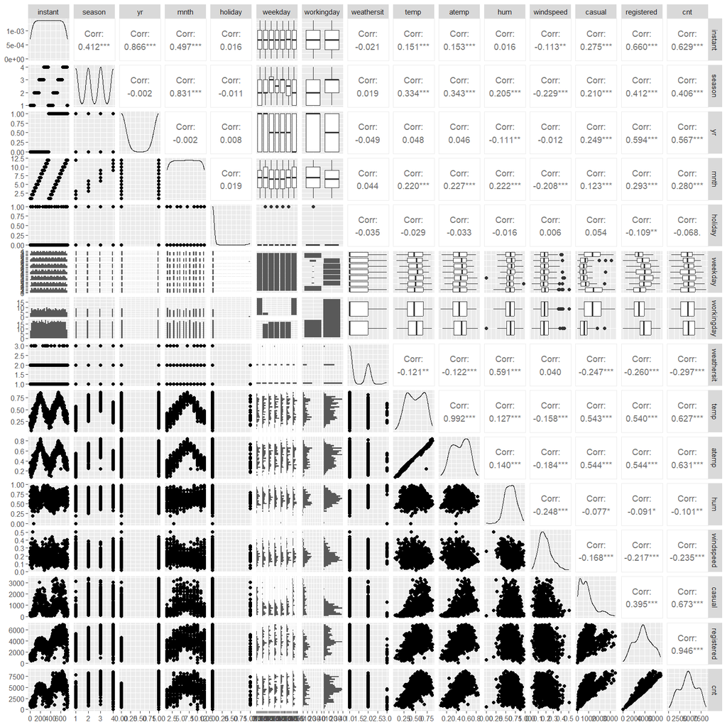

```r
library(GGally)
GGally::ggpairs(bikesharing[-c(2,17,18,19)])
```

Plotten Sie die Ausleihen gegen die Zeit, um den Verlauf genauer analysieren zu können.

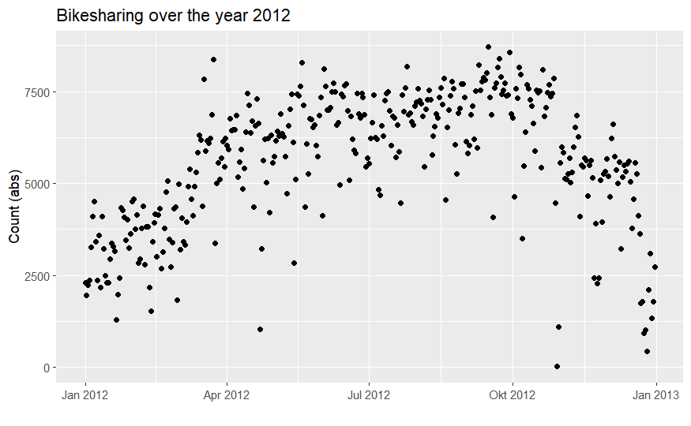

```r
ggplot(filter(bikesharing,yr==1), mapping=aes(x=dteday,y=cnt)) +
  geom_point()+
  labs(title="Bikesharing over the year 2012",x="",y="Count (abs)")
```

# Model training

## Lineares univariates Modell

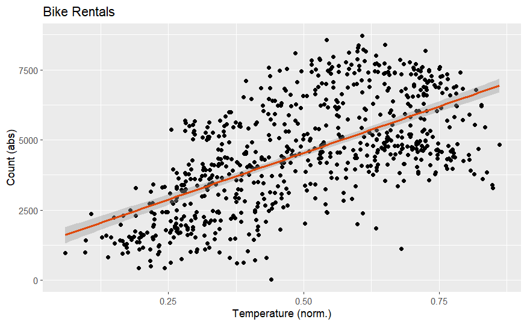

```r
ggplot(bikesharing, mapping=aes(x=temp,y=cnt)) +
  geom_point()+
  geom_smooth(method="lm",col="#DF4807")+
  labs(title="Bike Rentals",x="Temperature (norm.)",y="Count (abs)")
```

## Data Splitting

```r
set.seed(123)
trainIndex <- createDataPartition(bikesharing$cnt, p = 0.8, list = FALSE)
bikesharing_train <- bikesharing[trainIndex, ]
bikesharing_test <- bikesharing[-trainIndex, ]
```

## 10 fache Cross Validation

```r
library(caret)
library(randomForest)
trainControl <- trainControl(method="repeatedcv", number=10, repeats=3)
metric <- c("RMSE")
```

## Lineares multivariates Modell

```r
set.seed(7)
fit.lm <- train(cnt ~ temp + hum + windspeed + factor(weekday_fct) + holiday,data=bikesharing_train, method="lm",metric=metric, preProc=c("center",
"scale"), trControl=trainControl)
```

### Coefficient Plot

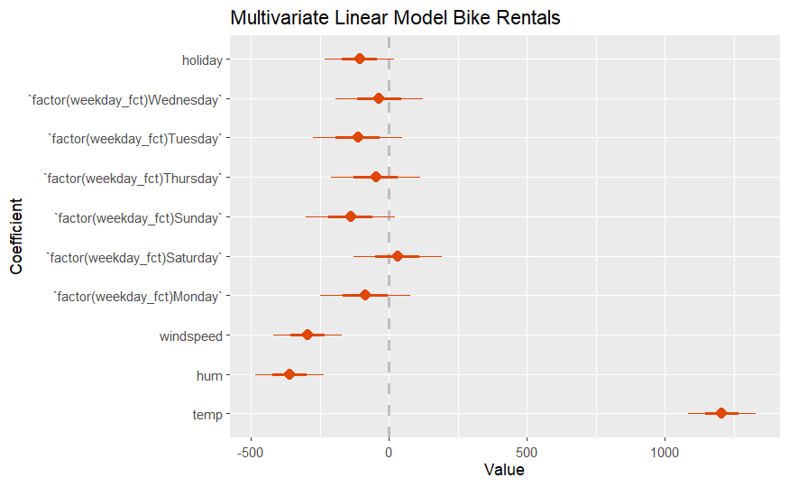

```r
library(coefplot)
coefplot(fit.lm, col="#DF4807",intercept=F) +
  labs(title="Multivariate Linear Model Bike Rentals")
```

## RF regression

```r
set.seed(7)
fit.rf <- train(cnt ~ temp + workingday + hum + windspeed + weekday, data=bikesharing_train, method="rf", metric=metric, preProc=c("center",
"scale"), trControl=trainControl)
```

### GLM regression

```r
set.seed(7)
fit.glm <- train(cnt ~ temp + workingday + hum + windspeed + weekday, data=bikesharing_train, method="glm", metric=metric, preProc=c("center",
"scale"), trControl=trainControl)
```

### SVM regression

```r
set.seed(7)
fit.svm <- train(cnt ~ temp + workingday + hum + windspeed + weekday, data=bikesharing_train, method="svmRadial", metric=metric,
preProc=c("center", "scale"), trControl=trainControl)
```

### CART regression

```r
set.seed(7)
grid <- expand.grid(.cp=c(0, 0.05, 0.1))
fit.cart <- train(cnt ~ temp + workingday + hum + windspeed + weekday, data=bikesharing_train, method="rpart", metric=metric, tuneGrid=grid,
preProc=c("center", "scale"), trControl=trainControl)
```

### KNN regression

```r
set.seed(7)
fit.knn <- train(cnt ~ temp + workingday + hum + windspeed + weekday, data=bikesharing_train, method="knn", metric=metric, preProc=c("center",
"scale"), trControl=trainControl)
```

## Compare algorithms for regression based on cross validation results

```r
results1 <- resamples(list(LM=fit.lm, GLM=fit.glm, SVM=fit.svm,
CART=fit.cart, KNN=fit.knn, RF=fit.rf))
summary(results1)
```

```
Call:
summary.resamples(object = results1)

Models: LM, GLM, SVM, CART, KNN, RF
Number of resamples: 30

MAE
          Min.  1st Qu.   Median     Mean  3rd Qu.     Max. NA's
LM   1052.8050 1118.094 1181.256 1195.792 1258.947 1375.058    0
GLM  1052.8050 1118.094 1181.256 1195.792 1258.947 1375.058    0
SVM  1001.2855 1085.621 1140.206 1142.498 1188.988 1343.975    0
CART 1042.4681 1123.177 1187.324 1199.935 1282.342 1391.766    0
KNN  1048.8475 1147.002 1201.283 1204.419 1254.706 1378.964    0
RF    950.0631 1028.811 1084.589 1100.998 1133.664 1341.434    0

RMSE
         Min.  1st Qu.   Median     Mean  3rd Qu.     Max. NA's
LM   1281.488 1379.631 1428.160 1450.284 1533.960 1647.274    0
GLM  1281.488 1379.631 1428.160 1450.284 1533.960 1647.274    0
SVM  1216.561 1284.744 1354.967 1345.496 1388.125 1526.890    0
CART 1270.214 1368.737 1445.246 1444.562 1531.565 1662.509    0
KNN  1246.230 1366.364 1411.542 1421.741 1477.131 1587.451    0
RF   1106.925 1209.926 1288.635 1297.819 1344.054 1576.731    0

Rsquared
          Min.   1st Qu.    Median      Mean   3rd Qu.      Max. NA's
LM   0.2483537 0.3860853 0.4495294 0.4383458 0.4980781 0.5571470    0
GLM  0.2483537 0.3860853 0.4495294 0.4383458 0.4980781 0.5571470    0
SVM  0.3614192 0.4820917 0.5296390 0.5225687 0.5601403 0.6440351    0
CART 0.2265054 0.3485037 0.4503080 0.4398038 0.5300338 0.5662992    0
KNN  0.2759867 0.4188247 0.4650282 0.4688462 0.5382023 0.6013488    0
RF   0.3187829 0.5229703 0.5651122 0.5491401 0.5993777 0.7115009    0
```

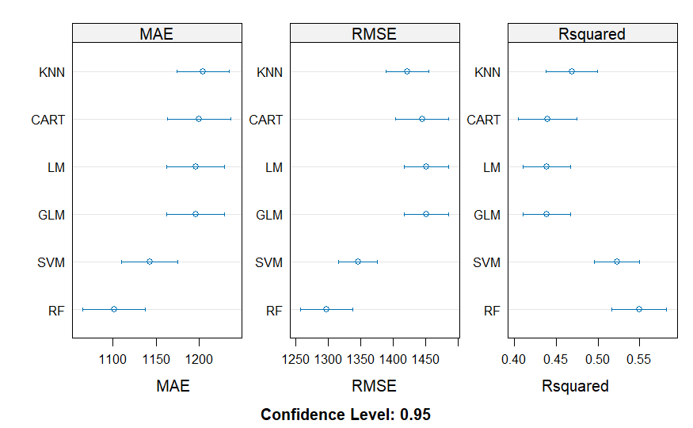

```r
scales <- list(x=list(relation="free"), y=list(relation="free"))
dotplot(results1,scales=scales)
```

## Model evaluation for classification based on cross validation results

Predict the season based on temperatur, hum, windspeed and counts

```r
# prepare training scheme
trainControl <- trainControl(method="repeatedcv", number=10, repeats=3)
# CART
set.seed(7)
fit.cart <- train(season_fct~temp+cnt+hum+windspeed, data=bikesharing_train, method="rpart",
trControl=trainControl)
# LDA
fit.lda <- train(season_fct~temp+cnt+hum+windspeed, data=bikesharing_train, method="lda", trControl=trainControl)
# SVM
fit.svm <- train(season_fct~temp+cnt+hum+windspeed, data=bikesharing_train, method="svmRadial",
trControl=trainControl)
# KNN
fit.knn <- train(season_fct~temp+cnt+hum+windspeed, data=bikesharing_train, method="knn", trControl=trainControl)
# Random Forest
fit.rf <- train(season_fct~temp+cnt+hum+windspeed, data=bikesharing_train, method="rf", trControl=trainControl)
# collect resamples
results2 <- resamples(list(CART=fit.cart, LDA=fit.lda, SVM=fit.svm, KNN=fit.knn, RF=fit.rf))
```

```r
# summarize differences between modes
summary(results2)
```

```
Call:
summary.resamples(object = results2)

Models: CART, LDA, SVM, KNN, RF
Number of resamples: 30

Accuracy
          Min.   1st Qu.    Median      Mean   3rd Qu.      Max. NA's
CART 0.4827586 0.5447107 0.5714689 0.5773100 0.6059322 0.7627119    0
LDA  0.5172414 0.6159605 0.6521476 0.6579573 0.7106224 0.7627119    0
SVM  0.5254237 0.6206897 0.6551724 0.6647428 0.7039012 0.8474576    0
KNN  0.2711864 0.3728814 0.3931911 0.3928353 0.4406780 0.4827586    0
RF   0.5666667 0.6222969 0.6694915 0.6685343 0.7106224 0.7796610    0

Kappa
           Min.   1st Qu.    Median      Mean   3rd Qu.      Max. NA's
CART 0.30677291 0.3918522 0.4284358 0.4358283 0.4741895 0.6837672    0
LDA  0.35581119 0.4887296 0.5359166 0.5439315 0.6141848 0.6837672    0
SVM  0.36753446 0.4938514 0.5400476 0.5529468 0.6050172 0.7964737    0
KNN  0.02647736 0.1622362 0.1890646 0.1902063 0.2542373 0.3095238    0
RF   0.42222222 0.4966606 0.5591214 0.5581347 0.6145215 0.7057921    0
```

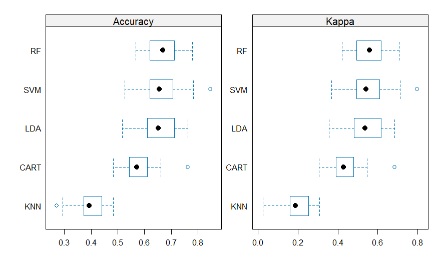

```r
# box and whisker plots to compare models
scales <- list(x=list(relation="free"), y=list(relation="free"))
bwplot(results2, scales=scales)
```

# Model testing with test data

## Regression testing

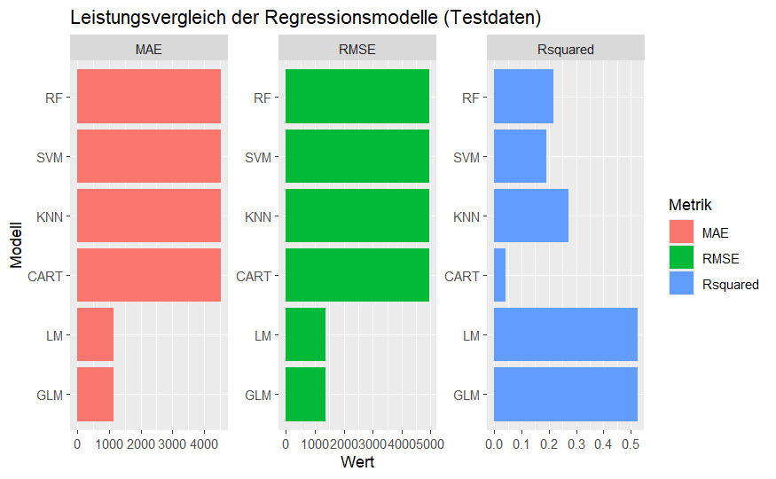

```r
library(caret)
library(dplyr)
library(tidyr)
library(ggplot2)

# --- Vorhersagen auf Testdaten ---
pred.lm   <- predict(fit.lm,  newdata = bikesharing_test)
pred.glm  <- predict(fit.glm, newdata = bikesharing_test)
pred.rf   <- predict(fit.rf,  newdata = bikesharing_test)
pred.svm  <- predict(fit.svm, newdata = bikesharing_test)
pred.cart <- predict(fit.cart, newdata = bikesharing_test)
pred.knn  <- predict(fit.knn, newdata = bikesharing_test)

# --- Wahre Werte ---
obs.reg <- bikesharing_test$cnt

# --- Sicherstellen, dass alles numerisch ist ---
obs.reg <- as.numeric(obs.reg)
pred.lm <- as.numeric(pred.lm)
pred.glm <- as.numeric(pred.glm)
pred.rf <- as.numeric(pred.rf)
pred.svm <- as.numeric(pred.svm)
pred.cart <- as.numeric(pred.cart)
pred.knn <- as.numeric(pred.knn)

# --- Fehlermaße berechnen ---
results_reg <- data.frame(
  Modell = c("LM", "GLM", "RF", "SVM", "CART", "KNN"),
  RMSE = c(
    RMSE(pred.lm, obs.reg),
    RMSE(pred.glm, obs.reg),
    RMSE(pred.rf, obs.reg),
    RMSE(pred.svm, obs.reg),
    RMSE(pred.cart, obs.reg),
    RMSE(pred.knn, obs.reg)
  ),
  Rsquared = c(
    R2(pred.lm, obs.reg),
    R2(pred.glm, obs.reg),
    R2(pred.rf, obs.reg),
    R2(pred.svm, obs.reg),
    R2(pred.cart, obs.reg),
    R2(pred.knn, obs.reg)
  ),
  MAE = c(
    MAE(pred.lm, obs.reg),
    MAE(pred.glm, obs.reg),
    MAE(pred.rf, obs.reg),
    MAE(pred.svm, obs.reg),
    MAE(pred.cart, obs.reg),
    MAE(pred.knn, obs.reg)
  )
)

# --- Daten ins Long-Format bringen für ggplot ---
results_reg_long <- pivot_longer(results_reg, -Modell, names_to = "Metrik", values_to = "Wert")

# --- Visualisierung ---
ggplot(results_reg_long, aes(x = reorder(Modell, Wert), y = Wert, fill = Metrik)) +
  geom_bar(stat = "identity", position = "dodge") +
  facet_wrap(~Metrik, scales = "free") +
  labs(title = "Leistungsvergleich der Regressionsmodelle (Testdaten)",
       x = "Modell", y = "Wert") +
  coord_flip()
```

## Classification testing

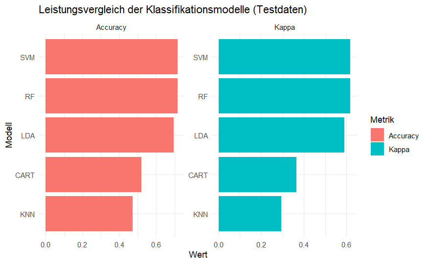

```r
# --- Wahre Klassenlabels ---
obs.class <- as.factor(bikesharing_test$season_fct)  # Absicherung: Zielvariable als Faktor

# --- Vorhersagen auf Testdaten (sicher als Faktor) ---
pred.cart <- as.factor(predict(fit.cart, newdata = bikesharing_test))
pred.lda  <- as.factor(predict(fit.lda,  newdata = bikesharing_test))
pred.svm  <- as.factor(predict(fit.svm,  newdata = bikesharing_test))
pred.knn  <- as.factor(predict(fit.knn,  newdata = bikesharing_test))
pred.rf   <- as.factor(predict(fit.rf,   newdata = bikesharing_test))

# --- Metriken mit postResample ---
results_class <- data.frame(
  Modell = c("CART", "LDA", "SVM", "KNN", "RF"),
  Accuracy = c(
    postResample(pred.cart, obs.class)["Accuracy"],
    postResample(pred.lda,  obs.class)["Accuracy"],
    postResample(pred.svm,  obs.class)["Accuracy"],
    postResample(pred.knn,  obs.class)["Accuracy"],
    postResample(pred.rf,   obs.class)["Accuracy"]
  ),
  Kappa = c(
    postResample(pred.cart, obs.class)["Kappa"],
    postResample(pred.lda,  obs.class)["Kappa"],
    postResample(pred.svm,  obs.class)["Kappa"],
    postResample(pred.knn,  obs.class)["Kappa"],
    postResample(pred.rf,   obs.class)["Kappa"]
  )
)

# --- Daten ins Long-Format für ggplot ---
results_class_long <- pivot_longer(results_class, -Modell, names_to = "Metrik", values_to = "Wert")

# --- Visualisierung ---
ggplot(results_class_long, aes(x = reorder(Modell, Wert), y = Wert, fill = Metrik)) +
  geom_bar(stat = "identity", position = "dodge") +
  facet_wrap(~Metrik, scales = "free") +
  labs(title = "Leistungsvergleich der Klassifikationsmodelle (Testdaten)",
       x = "Modell", y = "Wert") +
  theme_minimal() +
  coord_flip()
```

Sie sind am Ende des Notebooks angelangt.

```r
print("Done")
```

```
[1] "Done"
```